# P2P workshop

Antonio Fernandez-Guerra & Pelin Yilmaz

11/10/2017

# 1 Why R?

From the [r-project about page](https://www.r-project.org/about.html)…

R is a language and environment for statistical computing and graphics. R provides a wide variety of statistical (linear and nonlinear modelling, classical statistical tests, time-series analysis, classification, clustering, …) and graphical techniques, and is highly extensible. And it’s free. Also provides:

- an effective data handling and storage facility
- a suite of operators for calculations on arrays, in particular matrices
- a large, coherent, integrated collection of intermediate tools for data analysis, graphical facilities for data analysis and display either on-screen or on hardcopy
- a well-developed, simple and effective programming language which includes conditionals, loops, user-defined recursive functions and input and output facilities

In addition, R has a large community that develops solutions for many different fields from economics to biology, many of those solutions (packages) are contributed to the [Comprehensive R Archive Network (CRAN)](https://cran.r-project.org/). R has many *pros*, but also some *cons*:

- steep learning curve
- slow and can consume lot of memory

# 2 Basic R

We will cover the following topics:

- Getting help with R
- Assignment
- Data structures
- Subsetting
- Flow controls
- Functions
- Packages

A very useful resource are the [R cheat sheets](https://www.rstudio.com/resources/cheatsheets/) from Rstudio

## 2.1 Getting help with R

Almost every function in R is documented and you will find an extensive description with examples about what the function does. You can use the function **help()** or **?** to access to the documentation. The R project has a great explantion [here](https://www.r-project.org/help.html). Examples:

```r
help(matrix)
?matrix
```

## 2.2 Assignment

In R we use the operator **<-** to assign a value to the variable on the left side. The value can be an integer (i), double (d), string (s) or a boolean (b). Let’see how it works:

```r
i <- 42
i
```

```
## [1] 42
```

```r
d <- 4.2
d
```

```
## [1] 4.2
```

```r
s <- 'P2P workshop'
s
```

```
## [1] "P2P workshop"
```

```r
b <- TRUE
b
```

```
## [1] TRUE
```

A good explanation about the different data types can be found [here](http://www.dataperspective.info/2016/02/basic-data-types-in-r.html)

## 2.3 Data structures

In R we have different data structures, the most used are **Vectors**, **Lists**, **Matrices** and **Data Frames**. Hadley Wickham has a nice article describing each data structure [here](http://adv-r.had.co.nz/Data-structures.html)

### 2.3.1 Vectors

Vectors are the basic data structures in R. Here we will describe the so called *atomic vectors*. Atomic vectors are 1-dimension and all elements contained must be the same type (integer, double, logical or character). Vectors can be created using the function **c()** to concatenate different variables in a vector. Let’s see some examples:

```r
v_integer <- c(1, 2, 3)
v_integer
```

```
## [1] 1 2 3
```

```r
v_integer <- 1:3
v_integer
```

```
## [1] 1 2 3
```

```r
v_double <- c(1.2, 3.4, 5.6)
v_double
```

```
## [1] 1.2 3.4 5.6
```

```r
v_logical <- c(TRUE, FALSE, TRUE)
v_logical
```

```
## [1]  TRUE FALSE  TRUE
```

```r
v_character <- c("P2P", "workshop", "Bremen")
v_character
```

```
## [1] "P2P"      "workshop" "Bremen"
```

We can add elements to the end of a vector:

```r
v_integer <- c(1, 2, 3)
v_integer[4] <- 4
v_integer
```

```
## [1] 1 2 3 4
```

We can check the length of the vector with the function **length()**:

```r
length(v_integer)
```

```
## [1] 4
```

### 2.3.2 Lists

Lists are also vectors but they differ from atomic vectors that they can contain elements of different types, even lists. Instead of the function **c()** lists are created with **list()**. Let’s see some examples:

```r
l <- list(1:3, "a", c(TRUE, FALSE, TRUE), c(2.3, 5.9))
l
```

```
## [[1]]
## [1] 1 2 3
##
## [[2]]
## [1] "a"
##
## [[3]]
## [1]  TRUE FALSE  TRUE
##
## [[4]]
## [1] 2.3 5.9
```

Let’s check the type of the different elements in the list:

```r
str(l)
```

```
## List of 4
##  $ : int [1:3] 1 2 3
##  $ : chr "a"
##  $ : logi [1:3] TRUE FALSE TRUE
##  $ : num [1:2] 2.3 5.9
```

Elements of a list can be named:

```r
l_named <- list(int = 1:3, char = "a", bool = c(TRUE, FALSE, TRUE), dbl = c(2.3, 5.9))
l_named
```

```
## $int
## [1] 1 2 3
##
## $char
## [1] "a"
##
## $bool
## [1]  TRUE FALSE  TRUE
##
## $dbl
## [1] 2.3 5.9
```

### 2.3.3 Matrices

A Matrix is a two dimensional data structure, similar to vectors but it contains the dimension attribute. Each column in a matrix should contain the same data type. Matrices are specially used for mathematical operations. A matrix can be created with the function **matrix()**. Let’s see some exmaples:

```r
m <- matrix(1:6, ncol = 3, nrow = 2)
m
```

```
##      [,1] [,2] [,3]
## [1,]    1    3    5
## [2,]    2    4    6
```

We can assign names to rows and columns:

```r
rownames(m) <- c("A", "B")
colnames(m) <- c("a", "b", "c")
m
```

```
##   a b c
## A 1 3 5
## B 2 4 6
```

Or check the dimensions of our matrix using **dim()**:

```r
dim(m)
```

```
## [1] 2 3
```

### 2.3.4 Data Frames

A data frame is the most common way of storing data in R. A data frame is basically a list of equal-length vectors. It’s a 2-dimensional structure, so it shares properties of both the matrix and the list.

```r
df <- data.frame(x = 1:3, y = c("a", "b", "c"))
df
```

```
##   x y
## 1 1 a
## 2 2 b
## 3 3 c
```

**Tip**: Always try to define the correct size of vectors, matrices… It will be much faster than let R dynamically grow your data structure. For more info [here](http://www.burns-stat.com/documents/books/the-r-inferno/) or [here](http://menugget.blogspot.de/2011/11/another-aspect-of-speeding-up-loops-in.html)

## 2.4 Subsetting

R keeps an index of any of the elements in the different data structures and we can use subsetting to select or exclude any of these elements. [Here](http://www.statmethods.net/management/subset.html) and [here](http://adv-r.had.co.nz/Subsetting.html) you can find very good explanations about subsetting the different data structures using the subsetting operators **[**, **$** or **[[**.

For the most simple data structures, *vectors*, we can use the operator **[** to get the elements by their position or index. Positions in R starts at 1. For example let’s get the second element of *v_character*:

```r
v_character
```

```
## [1] "P2P"      "workshop" "Bremen"
```

```r
v_character[2]
```

```
## [1] "workshop"
```

Or the second and third:

```r
v_character[2:3]
```

```
## [1] "workshop" "Bremen"
```

In the case we don’t specify anything we will get the original vector:

```r
v_character[]
```

```
## [1] "P2P"      "workshop" "Bremen"
```

For *lists* we can use the operator **[**, that will return a list or **[[** and **$** that will return the elements of the list. Let’s see some examples with the **l_named** we created before:

```r
l_named
```

```
## $int
## [1] 1 2 3
##
## $char
## [1] "a"
##
## $bool
## [1]  TRUE FALSE  TRUE
##
## $dbl
## [1] 2.3 5.9
```

Let’s get the elements in postion 3 in the list **l_named**:

```r
l_named[3]
```

```
## $bool
## [1]  TRUE FALSE  TRUE
```

```r
class(l_named)
```

```
## [1] "list"
```

We can see that the returned oject after subseeting is a list (use **?class** to learn more about it). But if we want to get the elements in position 3 we should use **[[3]]** or as we have a named list we can use **$bool**. Let’s see an example:

```r
l_named[[3]]
```

```
## [1]  TRUE FALSE  TRUE
```

```r
l_named$bool
```

```
## [1]  TRUE FALSE  TRUE
```

```r
class(l_named[[3]])
```

```
## [1] "logical"
```

```r
class(l_named$bool)
```

```
## [1] "logical"
```

Now we are accessing to the elements and *class* is telling us that is a logical vector.

For *matrices* and *data frames* are similar than for vectors, but here we have to dimensions and when using the operator **[** we need to specify rows and columns this way **[row, column]**. Let’s see some examples with our data frame **df** that has three rows and two columns:

```r
df
```

```
##   x y
## 1 1 a
## 2 2 b
## 3 3 c
```

Let’s get first row:

```r
df[1,]
```

```
##   x y
## 1 1 a
```

And second column:

```r
df[,2]
```

```
## [1] a b c
## Levels: a b c
```

Or the element in the third row and second column:

```r
df[3, 2]
```

```
## [1] c
## Levels: a b c
```

As you can see in the result we get an extra line with **Levels: a b c**. Those are factors, another data type that is very important and useful but we will not cover in this course, but you can learn more about them [here](http://rforpublichealth.blogspot.de/2012/11/data-types-part-3-factors.html)

## 2.5 Flow control

R also have flow control structures like other programming languages. We will see: - If-Then-Else - For Loop - While Loop

### 2.5.1 If-Then-Else

If-Then-Else is a conditional structure than allows us to compare different variables and test them if they are true. A pseudo-code of an If-Then-Else estatement can be:

```
if (condition) {
    # do something
} else {
    # do something else
}
```

An example in R comparing the values of **x** and **y**:

```r
x <- 10
y <- 15
if (x < y) {
    print("x is smaller than y")
} else {
    print("x is greater than y")
}
```

```
## [1] "x is smaller than y"
```

It also can be vectorized:

```r
x <- 10
y <- 15
ifelse(x < y, "x is smaller than y", "x is greater than y")
```

```
## [1] "x is smaller than y"
```

### 2.5.2 For Loop

A for loop will repeat a specific block of code a known number of times iterating over a range of values.

```r
for (i in 1:10) {
    print(i)
}
```

```
## [1] 1
## [1] 2
## [1] 3
## [1] 4
## [1] 5
## [1] 6
## [1] 7
## [1] 8
## [1] 9
## [1] 10
```

We can iterate over a vector of characters:

```r
capitals <- c("Berlin", "London", "Madrid", "Paris")

for (i in capitals) {
    print(i)
}
```

```
## [1] "Berlin"
## [1] "London"
## [1] "Madrid"
## [1] "Paris"
```

Or we can use their indices and access to the elements in a similar fashion we learn in the subsetting section:

```r
capitals
```

```
## [1] "Berlin" "London" "Madrid" "Paris"
```

```r
length(capitals)
```

```
## [1] 4
```

Here we are using the values from *1* to *4* (length of the *capitals* vectors) that will be stored in the variable **i** to iterate over the vector *capitals*

```r
for (i in 1:length(capitals)) {
    print(capitals[i])
}
```

```
## [1] "Berlin"
## [1] "London"
## [1] "Madrid"
## [1] "Paris"
```

We also can use the function **seq** to generate the numerical sequence of the vector *capitals*, from 1 to 4:

```r
seq(capitals)
```

```
## [1] 1 2 3 4
```

```r
for (i in seq(capitals)) {
    print(capitals[i])
}
```

```
## [1] "Berlin"
## [1] "London"
## [1] "Madrid"
## [1] "Paris"
```

We also can write a more compact form:

```r
for (i in 1:4) print(capitals[i])
```

```
## [1] "Berlin"
## [1] "London"
## [1] "Madrid"
## [1] "Paris"
```

### 2.5.3 While Loop

A while loop is very similar to a for loop but the while loop will iterate until a condition is reached. Let’s see an example where we are summing *1* to the variable *i* while *i* is smaller than *10*. When we reach the condition, the while loop will stop.

```r
i <- 1
while (i < 10) {
    print(i)
    i <- i + 1
}
```

```
## [1] 1
## [1] 2
## [1] 3
## [1] 4
## [1] 5
## [1] 6
## [1] 7
## [1] 8
## [1] 9
```

Always be sure there is a way to exit out of a while loop if not it will run forever.

## 2.6 Functions

Functions are bits of R code that perform a very specific code, they will keep your code cleaner and will allow you to repeat this task easily. You already used different function in this tutorial like *seq*, *length*, *dim* and you can create your own functions very easily.

Let’s see some of the built-in functions that are useful to get the minimum, mean, median and maximum of a numerical vector:

```r
numbers <- c(1:10, 20:30)
min(numbers)
```

```
## [1] 1
```

```r
mean(numbers)
```

```
## [1] 15.71429
```

```r
median(numbers)
```

```
## [1] 20
```

```r
max(numbers)
```

```
## [1] 30
```

Let’s create our own function that calculates the mean of our numerical vector:

```r
my_mean <- function(arg1){
  total <- sum(arg1)
  n <- length(arg1)
  total/n
}
my_mean(arg1 = numbers)
```

```
## [1] 15.71429
```

Let’s check if we get the same results as the R built-in function:

```r
my_mean(numbers) == mean(numbers)
```

```
## [1] TRUE
```

Yay! It worked. Our new function **my_mean** requires one argument *arg1* (in our case a numerical vector) and returns the mean. For more information about functions check [here](https://nicercode.github.io/guides/functions/) and [here](http://adv-r.had.co.nz/Functions.html).

## 2.7 Packages

R community is generating lots of R code that performs a wide spectrum of analyses. They distribute this code in R packages. R packages can be retrieved from [The Comprehensive R Archive Network (CRAN)](https://cran.r-project.org/), from [Bioconductor](https://www.bioconductor.org/) or straight from [Github](https://github.com/) with devtools.

We can install packages from CRAN using **install.packages()**. Let’s see how we would install [**vegan**](https://cran.r-project.org/web/packages/vegan/index.html) the Community Ecology Package from Jari Oksanen that contains many useful methods for numerical ecology:

```r
install.packages("vegan")
```

Once the package is installed we can load their functions using **library()** and we will be ready to perform our analyses:

```r
library(vegan)
```

If we want to install packages from Bioconductor is a bit different. Bioconductor is a repository with many packages related to genomics (and microbiome analyses). Bioconductor has it’s own tool **biocLite** that will retrieve and install the package. Let’s install [phyloseq](http://bioconductor.org/packages/release/bioc/html/phyloseq.html) a tool for *handling and analysis of high-throughput microbiome census data* that we will use later:

```r
source("http://bioconductor.org/biocLite.R")
biocLite("phyloseq")
```

And we can load phyloseq with:

```r
library(phyloseq)
```

Another method is to install the packages straight from a github repository. Hadley Wickham has developed devtools to make it a painless process. As example we will install oligo4fun, a package to perform *pre-oligotyping diagnostics for functional genes* from my github repository (shameless self-promotion) using **install_github()**. First we need to install *devtools* from CRAN and load it:

```r
install.packages("devtools")
library(devtools)
```

And install oligo4fun from github:

```r
install_github("genomewalker/oligo4fun")
```

# 3 Tidyverse

Hadley Wickham proposed four basic principles that any computer interface for data management in R should follow in [the tidy tools manifesto](https://cran.r-project.org/web/packages/tidyverse/vignettes/manifesto.html):

- Reuse existing data structures
- Compose simple functions with the pipe
- Embrace functional programming
- Designed for humans

Recently he published [tidyverse](https://blog.rstudio.org/2016/09/15/tidyverse-1-0-0/) a collection of packages that follow those principles. In his book [R for data science](http://r4ds.had.co.nz/) showns how effective are those principles when using R for data science. Tidyverse loads the following packages:

- [readr](https://cran.r-project.org/web/packages/readr/index.html): to import data from files
- [tibble](https://cran.r-project.org/web/packages/tibble/index.html): better data frames
- [tidyr](https://cran.r-project.org/web/packages/tidyr/index.html): data tidying and rearrangement
- [dplyr](https://cran.r-project.org/web/packages/dplyr/index.html): a fast, consistent tool for working with data frame like objects
- [purr](https://cran.r-project.org/web/packages/purrr/index.html): extend R fucntional programming capabilities
- [ggplot2](https://cran.r-project.org/web/packages/ggplot2/index.html): data visualization using the grammar of graphics

Here I will briefly introduce dplyr and ggplot, although during the tutorial we will use a combination of all.

## 3.1 dplyr

Dplyr is a package that facilitates working with data frames or tibbles, key data structures in statistics and R. Usually in the data frames we will use, we will have one observation per row and columns will contain that represent a variable or measure or chracteristic. The most interesting (and useful) thing about dplyr is that provides “verbs” for data manipulation that helps to translate what you want to do to code. And dplyr is very fast!

The dplyr verbs are:

- **select**: return a subset of the columns of a data frame
- **filter**: extract a subset of rows from a data frame based on logical conditions
- **arrange**: reorder rows of a data frame
- **rename**: rename variables in a data frame
- **mutate**: add new variables/columns or transform existing variables
- **summarise** / summarize: generate summary statistics of different variables in the data frame, possibly within strata
- **group_by**: breaks down a dataset into specified groups of rows

All verbs share a similar syntax:

- The first argument is a data frame.
- The subsequent arguments describe what to do with the data frame. Notice that you can refer to columns in the data frame directly without using $.
- The result is a new data frame

### 3.1.1 Examples

The dplyr [vignette](https://cran.rstudio.com/web/packages/dplyr/vignettes/introduction.html) has a very nice example of how to use all the different verbs, but lets show a few of them here using the same data *nycflights13* (get more information with **?nycflights13**).

First we will install tidyverse and the data:

```r
install.packages(c("tidyverse","nycflights13"))
```

```r
library(tidyverse)
library(nycflights13)
```

And have a look:

```r
dim(flights)
```

```
## [1] 336776     19
```

```r
head(flights)
```

```
## # A tibble: 6 x 19
##    year month   day dep_time sched_dep_time dep_delay arr_time
##   <int> <int> <int>    <int>          <int>     <dbl>    <int>
## 1  2013     1     1      517            515         2      830
## 2  2013     1     1      533            529         4      850
## 3  2013     1     1      542            540         2      923
## 4  2013     1     1      544            545        -1     1004
## 5  2013     1     1      554            600        -6      812
## 6  2013     1     1      554            558        -4      740
## # ... with 12 more variables: sched_arr_time <int>, arr_delay <dbl>,
## #   carrier <chr>, flight <int>, tailnum <chr>, origin <chr>, dest <chr>,
## #   air_time <dbl>, distance <dbl>, hour <dbl>, minute <dbl>,
## #   time_hour <dttm>
```

A quite big data set. Let’s try the verb **filter** to select the flights on November 25th:

```r
filter(flights, month == 11, day == 25)
```

```
## # A tibble: 942 x 19
##     year month   day dep_time sched_dep_time dep_delay arr_time
##    <int> <int> <int>    <int>          <int>     <dbl>    <int>
##  1  2013    11    25        5           2359         6      436
##  2  2013    11    25      508            500         8      647
##  3  2013    11    25      513            515        -2      801
##  4  2013    11    25      537            540        -3      827
##  5  2013    11    25      542            545        -3      845
##  6  2013    11    25      550            600       -10      843
##  7  2013    11    25      550            600       -10      647
##  8  2013    11    25      551            550         1     1019
##  9  2013    11    25      553            600        -7      657
## 10  2013    11    25      553            600        -7      826
## # ... with 932 more rows, and 12 more variables: sched_arr_time <int>,
## #   arr_delay <dbl>, carrier <chr>, flight <int>, tailnum <chr>,
## #   origin <chr>, dest <chr>, air_time <dbl>, distance <dbl>, hour <dbl>,
## #   minute <dbl>, time_hour <dttm>
```

We got 942 flights, let’s check how we would do it in base R:

```r
flights[flights$month == 11 & flights$day == 25, ]
```

```
## # A tibble: 942 x 19
##     year month   day dep_time sched_dep_time dep_delay arr_time
##    <int> <int> <int>    <int>          <int>     <dbl>    <int>
##  1  2013    11    25        5           2359         6      436
##  2  2013    11    25      508            500         8      647
##  3  2013    11    25      513            515        -2      801
##  4  2013    11    25      537            540        -3      827
##  5  2013    11    25      542            545        -3      845
##  6  2013    11    25      550            600       -10      843
##  7  2013    11    25      550            600       -10      647
##  8  2013    11    25      551            550         1     1019
##  9  2013    11    25      553            600        -7      657
## 10  2013    11    25      553            600        -7      826
## # ... with 932 more rows, and 12 more variables: sched_arr_time <int>,
## #   arr_delay <dbl>, carrier <chr>, flight <int>, tailnum <chr>,
## #   origin <chr>, dest <chr>, air_time <dbl>, distance <dbl>, hour <dbl>,
## #   minute <dbl>, time_hour <dttm>
```

We can see that using **filter** is closer to our natural language and this will help when we review our code after few months.

Let’s try now the **arrange** verb to sort the data frame by year, month and day:

```r
arrange(flights, year, month, day)
```

```
## # A tibble: 336,776 x 19
##     year month   day dep_time sched_dep_time dep_delay arr_time
##    <int> <int> <int>    <int>          <int>     <dbl>    <int>
##  1  2013     1     1      517            515         2      830
##  2  2013     1     1      533            529         4      850
##  3  2013     1     1      542            540         2      923
##  4  2013     1     1      544            545        -1     1004
##  5  2013     1     1      554            600        -6      812
##  6  2013     1     1      554            558        -4      740
##  7  2013     1     1      555            600        -5      913
##  8  2013     1     1      557            600        -3      709
##  9  2013     1     1      557            600        -3      838
## 10  2013     1     1      558            600        -2      753
## # ... with 336,766 more rows, and 12 more variables: sched_arr_time <int>,
## #   arr_delay <dbl>, carrier <chr>, flight <int>, tailnum <chr>,
## #   origin <chr>, dest <chr>, air_time <dbl>, distance <dbl>, hour <dbl>,
## #   minute <dbl>, time_hour <dttm>
```

And in base R:

```r
flights[order(flights$year, flights$month, flights$day), ]
```

```
## # A tibble: 336,776 x 19
##     year month   day dep_time sched_dep_time dep_delay arr_time
##    <int> <int> <int>    <int>          <int>     <dbl>    <int>
##  1  2013     1     1      517            515         2      830
##  2  2013     1     1      533            529         4      850
##  3  2013     1     1      542            540         2      923
##  4  2013     1     1      544            545        -1     1004
##  5  2013     1     1      554            600        -6      812
##  6  2013     1     1      554            558        -4      740
##  7  2013     1     1      555            600        -5      913
##  8  2013     1     1      557            600        -3      709
##  9  2013     1     1      557            600        -3      838
## 10  2013     1     1      558            600        -2      753
## # ... with 336,766 more rows, and 12 more variables: sched_arr_time <int>,
## #   arr_delay <dbl>, carrier <chr>, flight <int>, tailnum <chr>,
## #   origin <chr>, dest <chr>, air_time <dbl>, distance <dbl>, hour <dbl>,
## #   minute <dbl>, time_hour <dttm>
```

Now let’s use **select** to keep only the columns we are interested:

```r
select(flights, year, month, day)
```

```
## # A tibble: 336,776 x 3
##     year month   day
##    <int> <int> <int>
##  1  2013     1     1
##  2  2013     1     1
##  3  2013     1     1
##  4  2013     1     1
##  5  2013     1     1
##  6  2013     1     1
##  7  2013     1     1
##  8  2013     1     1
##  9  2013     1     1
## 10  2013     1     1
## # ... with 336,766 more rows
```

And if we want to know which is the average delay time, we can use **summarize**:

```r
summarise(flights, delay = mean(dep_delay, na.rm = TRUE))
```

```
## # A tibble: 1 x 1
##      delay
##      <dbl>
## 1 12.63907
```

Let’s have a look to the **group_by** verb. We will group the flights based on the plane tail numbers (split the dataset into individual planes):

```r
by_tailnum <- group_by(flights, tailnum)
```

And we will count the number of flights (count = n()), we will calculate the average distance (dist = mean(Distance, na.rm = TRUE)) and the average delay (delay = mean(ArrDelay, na.rm = TRUE)).

```r
delay <- summarise(by_tailnum,
  count = n(),
  dist = mean(distance, na.rm = TRUE),
  delay = mean(arr_delay, na.rm = TRUE))
delay
```

```
## # A tibble: 4,044 x 4
##    tailnum count     dist      delay
##      <chr> <int>    <dbl>      <dbl>
##  1  D942DN     4 854.5000 31.5000000
##  2  N0EGMQ   371 676.1887  9.9829545
##  3  N10156   153 757.9477 12.7172414
##  4  N102UW    48 535.8750  2.9375000
##  5  N103US    46 535.1957 -6.9347826
##  6  N104UW    47 535.2553  1.8043478
##  7  N10575   289 519.7024 20.6914498
##  8  N105UW    45 524.8444 -0.2666667
##  9  N107US    41 528.7073 -5.7317073
## 10  N108UW    60 534.5000 -1.2500000
## # ... with 4,034 more rows
```

### 3.1.2 Chaining

Last example is about chaining verbs. Lets say we want to the average dayly arrival and departure delay for our data set and filter all days when there is an average delay greater than 30 minutes. To achieve this we would follow the following steps:

1. Group by year, month and day
2. Select arrival and departure delay
3. Calculate the averages
4. Filter the days with an average delay (arrival or departure) larger than 30 minutes

Using dplyr that would be something like this:

```r
a1 <- group_by(flights, year, month, day)
a2 <- select(a1, arr_delay, dep_delay)
a3 <- summarise(a2,
  arr = mean(arr_delay, na.rm = TRUE),
  dep = mean(dep_delay, na.rm = TRUE))
a4 <- filter(a3, arr > 30 | dep > 30)
```

If we want to avoid having intermediate results we can do:

```r
filter(
  summarise(
    select(
      group_by(flights, year, month, day),
      arr_delay, dep_delay
    ),
    arr = mean(arr_delay, na.rm = TRUE),
    dep = mean(dep_delay, na.rm = TRUE)
  ),
  arr > 30 | dep > 30
)
```

```
## # A tibble: 49 x 5
## # Groups:   year, month [11]
##     year month   day      arr      dep
##    <int> <int> <int>    <dbl>    <dbl>
##  1  2013     1    16 34.24736 24.61287
##  2  2013     1    31 32.60285 28.65836
##  3  2013     2    11 36.29009 39.07360
##  4  2013     2    27 31.25249 37.76327
##  5  2013     3     8 85.86216 83.53692
##  6  2013     3    18 41.29189 30.11796
##  7  2013     4    10 38.41231 33.02368
##  8  2013     4    12 36.04814 34.83843
##  9  2013     4    18 36.02848 34.91536
## 10  2013     4    19 47.91170 46.12783
## # ... with 39 more rows
```

Well… this nested structure is not so easy to read and understand, and we can easily get lost. If you noticed, we need to read it from inside out. Luckily dplyr has the **%>%** operator or pipe, originally implemented in the [magrittr](https://cran.r-project.org/web/packages/magrittr/vignettes/magrittr.html) package and now re-implemented in dplyr (magrittr author is a co-author of dplyr). Using **%>%** rewrites multiple operations that we can read left-to-right, top-to-bottom:

```r
flights %>%
  group_by(year, month, day) %>%
  select(arr_delay, dep_delay) %>%
  summarise(
    arr = mean(arr_delay, na.rm = TRUE),
    dep = mean(dep_delay, na.rm = TRUE)
  ) %>%
  filter(arr > 30 | dep > 30)
```

```
## # A tibble: 49 x 5
## # Groups:   year, month [11]
##     year month   day      arr      dep
##    <int> <int> <int>    <dbl>    <dbl>
##  1  2013     1    16 34.24736 24.61287
##  2  2013     1    31 32.60285 28.65836
##  3  2013     2    11 36.29009 39.07360
##  4  2013     2    27 31.25249 37.76327
##  5  2013     3     8 85.86216 83.53692
##  6  2013     3    18 41.29189 30.11796
##  7  2013     4    10 38.41231 33.02368
##  8  2013     4    12 36.04814 34.83843
##  9  2013     4    18 36.02848 34.91536
## 10  2013     4    19 47.91170 46.12783
## # ... with 39 more rows
```

This is much nicer and now the code has a narrative that makes it much more easier to understand. Notice that now we are not using the the data frame as first parameter for the verb, as **flights %>% filter(month == 1)** turns into **filter(flights, month == 1)**

## 3.2 ggplot2

Besides basic R capabilities we can produce publication ready figures using [ggplot2](http://ggplot2.org/). Ggplot2 is a plotting system based on the grammar of graphics, which tries to take the good parts of base and lattice graphics and none of the bad parts. It takes care of many of the fiddly details that make plotting a hassle (like drawing legends) as well as providing a powerful model of graphics that makes it easy to produce complex multi-layered graphics.

We will see a basic example of the great capabilities of ggplot2 but if you want to learn more, check the [documentation](http://docs.ggplot2.org/current/) or Hadley’s book [ggplot2: Elegant Graphics for Data Analysis](http://amzn.com/0387981403?tag=ggplot2-20)

Let’s use the example where we calculated the average delay time by plane and now we filter those with a count > 20 and a distance < 2000:

```r
delay <- flights %>% group_by(tailnum) %>%
  summarise(count = n(),
            dist = mean(distance, na.rm = TRUE),
            delay = mean(arr_delay, na.rm = TRUE)) %>%
  filter(count > 20, dist < 2000)
```

And we will use ggplot2 to plot the results and explore if there is a relationship between the average delay and the average distance flown by the plane. Points are scaled by the number of flights of each plane and a generalized additive model has been used to fit the data.

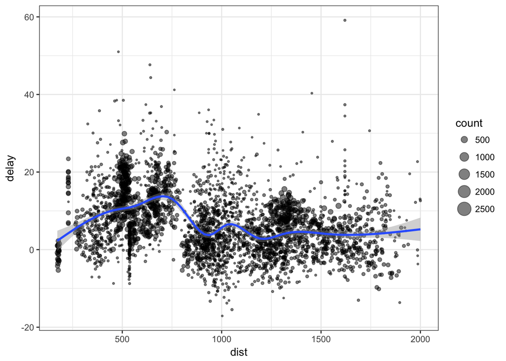

```r
ggplot(delay, aes(dist, delay)) +
  geom_point(aes(size = count), alpha = 1/2) +
  geom_smooth() +
  scale_size_area() +
  theme_bw()
```